# Coverage analysis

J. Ignacio Lucas Lledó

2023-07-06

## Introduction

I want to use `angsd` to estimate the site frequency spectra (SFS) of every *Coregonus* species, directly from the BAM files. I need to filter the BAM files, to remove poorly mapped reads. And I need to decide on the ancestral state of every variable position, in order to polarize the spectra. It would be nice to incorporate the uncertainty of the ancestral allele in the likelihood of the SFS. Aparantly the `est-sfs` program (Keightley and Jackson 2018) can do that. It accepts either two or three outgroups. Because Alpine and Arctic species are reciprocal outgroups, one of the *C. clupeaformis* genomes (Mérot et al., n.d.) can be used as a second outgroup. And the *Salmo salar* reference genome could be the third reference genome.

Mérot et al. (n.d.) sequenced two ecomorphs of the american *C. clupeaformis*. If the divergence in this species used variation also available in *C. lavaretus*, the use of only one of the ecomorphs as an outgroup would bias the polarization. Thus, I should use both. Actually, I could use more, because the programme `est-sfs` can use polymorphism data in the outgroup species.

I download the genome assemblies of the [dawrf](https://ftp.ncbi.nlm.nih.gov/genomes/all/GCF/020/615/455/GCF_020615455.1_ASM2061545v1/GCF_020615455.1_ASM2061545v1_genomic.fna.gz) and the [normal](https://ftp.ncbi.nlm.nih.gov/genomes/all/GCF/018/398/675/GCF_018398675.1_ASM1839867v1/GCF_018398675.1_ASM1839867v1_genomic.fna.gz) ecomorphs of *C. clupeaformis* from the NCBI ftp site. And also the [*Salmo salar* reference genome](https://ftp.ncbi.nlm.nih.gov/genomes/all/GCF/905/237/065/GCF_905237065.1_Ssal_v3.1/GCF_905237065.1_Ssal_v3.1_genomic.fna.gz).

We need to keep in mind that the *Coregonus* “Balchen” reference genome (De-Kayne, Zoller, and Feulner 2020), which belongs to the species currently known as *C. steinmanni*, is not perfect. The authors warn of the presence of *collapsed* regions: long stretches of chromosomes, or whole chromosomes, that must be duplicated in reality but are represented only once in the reference. Supplementary table 3 in De-Kayne, Zoller, and Feulner (2020) suggests the potentially collapsed regions are:

| chr. | start | end |
| --- | --- | --- |
| 4 | 0 | 31500000 |
| 7 | 39000000 | 65391737 |
| 17 | 41500000 | 54216998 |
| 22 | 0 | 56862223 |
| 28 | 0 | 46671285 |
| 32 | 0 | 44616205 |
| 35 | 0 | 42609905 |
| 37 | 32500000 | 43663377 |
| 38 | 0 | 36774138 |

## Coverage data

From the BAM files with only high quality-mapped reads, and using only sites with coverage of at least 6 reads per sample, I obtain depth of coverage in every sample, with `samtools depth`.

There is a problem: before mapping the reads to the reference, `ipyrad` *dereplicated* them. That is, collapsed identical reads in only one representative sequence, and tagged its name with the number of identical reads observed (the “size=X” label). Unfortunately, `samtools depth` does not take this *size* of a read into account, and therefore the depth is quite downwardly biased. This was probably the reason why coverage was so uniform along chromosomes before I realized. To solve the problem, I use the script `reduplicate.awk`, which takes a SAM file, expecting to see “size=1”, and repeating the reads if necessary with an updated read name.

```bash
BAMDIR=../2022-04-22/assem2_refmapping
COLLAPSED=../../data/collapsed.txt
FISHDATA=../../data/Fish_clean2.tsv
THEWORST=../2022-05-04/TheWorst.txt

if [ ! -e samples_available.txt ]; then
   ls -1 $BAMDIR | grep -v '.csi' | cut -d "-" -f 1 > samples_available.txt
fi

if [ ! -e samples.txt ]; then
   grep -v -F -f $THEWORST samples_available.txt > samples.txt
fi

if [ ! -e sample_lake_sp.txt ]; then
   grep -F -f samples.txt $FISHDATA | cut -f 1,2,19 | \
   gawk '($3 ~ /^[DLP]$/){
      $3 = substr($2, 1, 3) $3
   }{
      gsub(/\//, "-", $3)
      print $1 "\t" $2 "\t" $3}' > sample_lake_sp.txt
fi

if [ ! -e species.txt ]; then
   cut -f 3 sample_lake_sp.txt | sort | uniq > species.txt
fi

# I want to use only reads mapped with high confidence (MAPQ==60),
# and I want to add read group information to the BAM files.
for sp in $(cat species.txt); do
   if [ ! -d $sp ]; then mkdir $sp; fi
   if [ ! -e $sp/samples.txt ]; then
      gawk -v SP=$sp '($3 == SP){print $1}' sample_lake_sp.txt > $sp/samples.txt
   fi
   for sample in $(cat $sp/samples.txt); do
      if [ ! -e $sp/$sample.bam ]; then
         samtools view -h -q 60 $BAMDIR/${sample}-mapped-sorted.bam | \
         gawk -v OFS='\t' -f reduplicate.awk | \
         samtools view -u - | \
         samtools addreplacerg -o $sp/$sample.bam \
                               -r "@RG\tID:$sample\tSM:$sample" \
                               -O BAM \
                               --write-index - &
      fi
   done
   wait
   for sample in $(cat $sp/samples.txt); do
      if [ ! -e $sp/${sample}.depth ]; then
         # samtools depth prints chromosome, position and depth in every
         # position with coverage. I wrote an awk script to summarize the
         # information for every "locus" (continuous stretch with coverage >= 6).
         samtools depth $sp/${sample}.bam | \
         gawk -f depth.awk > $sp/${sample}.depth &
      fi
   done
   wait
done
if [ ! -e gaps.txt ]; then
   find . -name '*.depth' -exec grep -v 'chr' '{}' \; | \
   gawk 'BEGIN{
      LAST = 1
   }($2 < LAST){
      LAST = 1
   }{
      F[$2 - LAST]++
   }END{
      for (f in F) print f "\t" F[f]
   }' | sort -nk 1,1 > gaps.txt
fi
if [ ! -e lociLength.txt ]; then
   find . -name '*.depth' -exec grep -v 'chr' '{}' \; | \
   gawk '{F[$3 - $2 + 1]++}END{
      for (f in F) print f "\t" F[f]
   }' | sort -nk 1,1 > lociLength.txt
fi
```

## Chromosome-level duplications

Depth of coverage is reported per site. That’s an excessive amount of information, and I need to summarize it by locus, under the assumption that coverage along one locus is built up from the same set of reads, and must therefore be quite homogeneous, except for short deletions. (I suppose insertions are not reported: only positions in the reference can appear in the output). For example, a heterozygous individual for a short deletion inside a locus will show a two-fold change of coverage along that locus.

Deletions can also split a read among two loci, or open a short gap within the locus: it depends on what I consider a locus. Preliminar inspection of the coverage depth data suggests that many loci are within 400 bases from a neighbour locus. The paired nature of the reads must explain most of this proximity among loci, when strictly definied as stretches of continuously covered positions. I should relax the definition of a locus to include nearby covered segments, such as the two paired ends of a sequenced fragment. I decide on a maximum gap length of 450 bases within a locus (implemented in `depth.awk`).

Then I need to decide on a minimum length for a locus. Sometimes a locus has just enough reads to pass the minimum coverage in only one or a few bases, where an additional read overlaps. Such spuriously short loci must be removed from consideration. I decide the minimum length must be 60 bases.

Files named with the `.depth` sufix are, then summaries of coverage depth, with one value per *locus*, and with loci boundaries included as in a BED file. For the purpose of visualizing chromosome-level variations in copy number, I need to further summarize the information. With this purpose, I create the `DepthPerChr.txt` file.

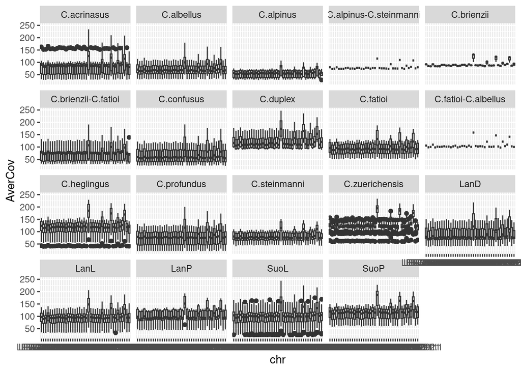

```r
library(ggplot2)
library(plyr)
library(kableExtra)
species <- read.table('species.txt', colClasses = 'character')$V1
if (! file.exists('DepthPerChr.txt')) {
   DepthPerChr <- data.frame(
      chr       = character(),
      sp        = character(),
      fish      = character(),
      MinCov    = double(),
      MaxCov    = double(),
      AverCov   = double(),
      SDCov     = double(),
      stringsAsFactors = FALSE
   )
   for (sp in species) {
      samples <- read.table(paste0(sp, "/samples.txt"),
                            colClasses = 'character')$V1
      for (fish in samples) {
         df1 <- read.table(paste0(sp, "/", fish, ".depth"), header = TRUE)
         df1$sp <- sp
         df1$fish <- fish
         df2 <- ddply(df1, .(chr, sp, fish), summarize,
                      MinCov  = min(MeanCov),
                      MaxCov  = max(MeanCov),
                      AverCov = mean(MeanCov),
                      SDCov   = sd(MeanCov))
         DepthPerChr <- rbind(DepthPerChr, df2)
      }
   }
   write.table(DepthPerChr, file = 'DepthPerChr.txt', sep = '\t',
               row.names = FALSE, quote = FALSE)
} else {
   DepthPerChr <- read.table('DepthPerChr.txt', header = TRUE)
}
ggplot(data = DepthPerChr,
       mapping = aes(x = chr, y = AverCov)) +
   geom_boxplot() + facet_wrap(~sp)
```

Some chromosomes have a clear effect on coverage. A statistical model may be the natural way to systematically identify the chromosomes that affect coverage in every sample. However, it is far from trivial to model the coverage data at hand: it depends in non-linear ways on the size of the locus, and it is very overdispersed. Plus, the model would have to be specified carfully for the estimated coefficients to be interpretable as fold-change or ploidy. The attempt below is just a rough approximation.

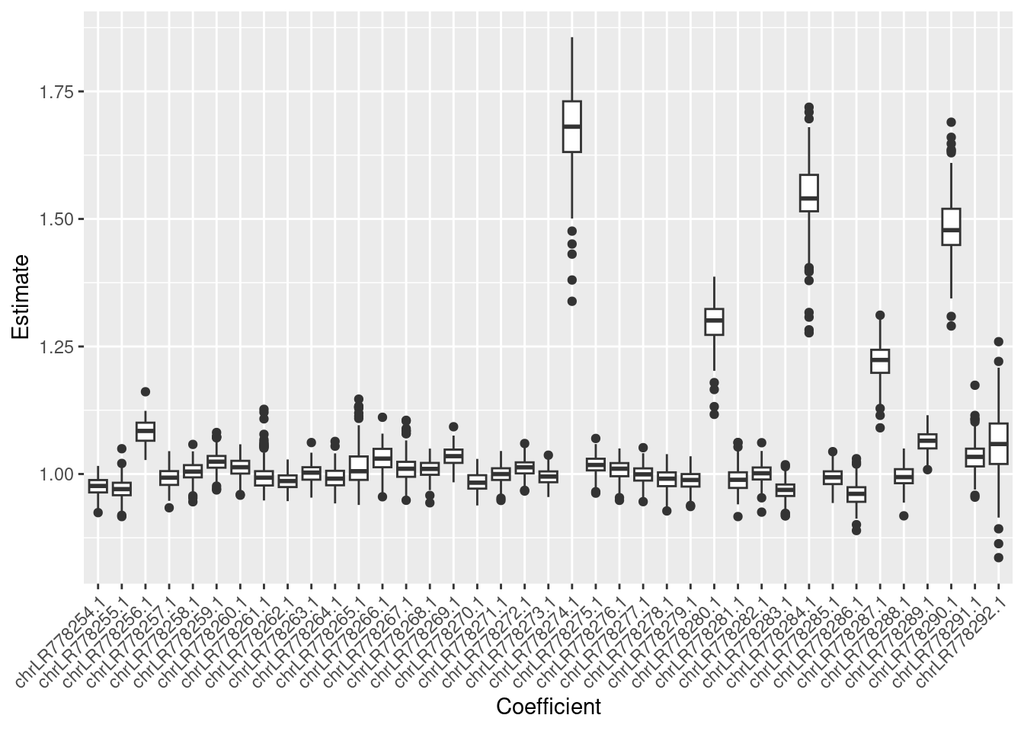

```r
if (! file.exists('CovModelCoef.txt')) {
   for (sp in species) {
      samples <- read.table(paste0(sp, "/samples.txt"),
                            colClasses = 'character')$V1
      for (fish in samples) {
         df <- read.table(paste0(sp, '/', fish, '.depth'),
                          header = TRUE)
         df$size <- df$end - df$start + 1
         df <- df[df$size >= 200 & df$size < 400, ]
         df$Cov <- round(df$MeanCov)  # for quasiPoisson modelling
         m0 <- glm(Cov ~ size + chr,
                   family = quasipoisson(link = 'log'),
                   data = df)
         z <- data.frame(
            Species = sp,
            Sample  = fish,
            Coefficient = rownames(coef(summary(m0))),
            Estimate = exp(coef(summary(m0))[,1])
         )
         if (exists('ModelCoef')) {
            ModelCoef <- rbind(ModelCoef, z)
         } else {
            ModelCoef <- z
         }
      }
   }
   write.table(ModelCoef, file = 'CovModelCoef.txt', quote = FALSE,
               sep = '\t', row.names = FALSE)
} else {
   ModelCoef <- read.table('CovModelCoef.txt', header = TRUE)
}
ggplot(data = ModelCoef[startsWith(as.character(ModelCoef$Coefficient), 'chr'), ],
       mapping = aes(x = Coefficient, y = Estimate)) +
   geom_boxplot() +
   theme(axis.text.x = element_text(angle = 45, hjust = 1, vjust = 1))
```

I conclude that the following chromosomes must be affected by global or very large partial duplications that are not distinguished in the reference genome:

| num | chromosome | effect |
| --- | --- | --- |
| 4 | LR778256.1 | 1.0827 |
| 22 | LR778274.1 | 1.6782 |
| 28 | LR778280.1 | 1.2967 |
| 32 | LR778284.1 | 1.5430 |
| 35 | LR778287.1 | 1.2210 |
| 37 | LR778289.1 | 1.0645 |
| 38 | LR778290.1 | 1.4834 |
| 40 | LR778292.1 | 1.0577 |

```r
if (! file.exists('Coverage.mp4')) {
   if (! file.exists('movie1')) {
      dir.create('movie1')
   }
   spNum  <- length(species)
   i <- 1  # chromosome number
   j <- 1  # species number
   for (sp in species) {
      samples <- read.table(paste0(sp, "/samples.txt"),
                            colClasses = 'character')$V1
      coverage <- data.frame(
         chr = character(),
         start = integer(),
         end = integer(),
         MeanCov = double(),
         midpoint = double(),
         species = character(),
         sample = character()
      )
      for (fish in samples) {
         df <- read.table(paste0(sp, '/', fish, '.depth'),
                          header = TRUE)
         df$midpoint <- (df$end + df$start) / 2
         df$species <- sp
         df$sample  <- fish
         coverage <- rbind(coverage, df)
      }
      i <- 1
      for (chr in levels(coverage$chr)) {
         position <- spNum * (i - 1) + j
         if (! file.exists(sprintf('movie1/img%03i.png', position))) {
            p <- ggplot(data = coverage[coverage$chr == chr, ],
                        mapping = aes(x = midpoint, y = MeanCov, color = sample)) +
               geom_smooth(method = 'loess') +
               ggtitle(sprintf("Cromosome %i (%s). %s", i, chr, sp)) +
               xlab('Position') + ylab('Coverage') +
               theme(legend.position = 'none')
            ggsave(sprintf('movie1/img%03i.png', position), p)
         }
         i <- i + 1
      }
      j <- j + 1
   }
   rm(coverage, p, df)
}
```

```bash
if [ ! -e Coverage.mp4 ]; then
   ffmpeg -framerate 1 -i movie1/img%03d.png \
          -c:v libx264 -r 1 Coverage.mp4
fi
```

## What loci to use

We cannot detect small-scale changes in copy number, because loci are sparse (they give low resolution) and coverage is overdispersed. But we could remove loci with extremely high coverage, as well as loci in chromosomes suspected to have anomalous copy number. I would like to keep those chromosomes for the moment, in order to check later if they have higher levels of observed variation.

I will also keep working separately on each sample, to keep *private* sites. Loci that appear in one or few samples are expected to be low-coverage loci from small fragments randomly picked in the size-selection step of library preparation. But some large, high-coverage loci may be private to some species as a consequence of divergence in restriction sites.

## Ancestral allele

I need the species-specific VCFs, and I want to generate them from the filtered and read-group-informed BAM files here. I remove filters that only act upon variable positions, in order to minimize the ascertainment bias of variation. After obtaining the VCFs, I will need to produce the input data files for `est-sfs`. Another challenge is how to get outgroup genotypes for the very same positions, in the same order.

After several attempts, where `freebayes` was not producing useful informatio, I realize the output VCFs could be huge if I request all positions in all species. I take advantage of the results in folder `2022-12-20`, already available at the time of writing: the sets of loci shared or not among samples of every species. I will limit the analysis to sites covered by at least 6 reads in every sample from the same species.

```bash
for sp in $(cat species.txt); do
   if [ ! -e $sp/$sp.vcf ]; then
      if [ ! -e $sp/BAMlist.txt ]; then
         ls -1 $sp/*.bam > $sp/BAMlist.txt
      fi
      freebayes -L $sp/BAMlist.txt \
                -f ../../data/reference.fa \
                -t ../2022-12-20/$sp/common.loci \
                --report-monomorphic \
                -T 0.002 \
                -4 \
                -F 0.0 \
                -C 0 > $sp/$sp.vcf &
   fi
done
wait

for sp in $(cat species.txt); do
   if [ ! -e $sp/sfs-input.txt ]; then
      if [ ! -e $sp/focal.txt ]; then
         NUMSAMPLES=$(ls -1 $sp/*.bam | wc -l)
         DOWNSIZE=$(echo "0.8 * $NUMSAMPLES / 1" | bc)
         gawk -v N=$DOWNSIZE -f get-focal-data.awk $sp/$sp.vcf > $sp/focal.txt &
      fi
      if [ ! -e $sp/outgroup1.txt ]; then
         echo "Work in progress"
      fi
      if [ ! -e $sp/outgroup2.txt ]; then
         echo "Work in progress"
      fi
   fi
done
wait
```

[output not shown]

[output cut: 102 more lines]

```
## Work in progress
## Work in progress
## Work in progress
## Work in progress
## Work in progress
## Work in progress
## Work in progress
## Work in progress
## Work in progress
## Work in progress
## Work in progress
## Work in progress
## Work in progress
## Work in progress
## Work in progress
```

Reading the documentation of `est-sfs`, I realize I cannot use simultaneously two sequences of the same outgroup species.

# References

De-Kayne, R., S. Zoller, and P. G. D. Feulner. 2020. “A de novo chromosome-level genome assembly of Coregonus sp. ’Balchen’: One representative of the Swiss Alpine whitefish radiation.” *Molecular Ecology Resources* 20 (4): 1093–1109. https://doi.org/10.1111/1755-0998.13187.

Keightley, P. D., and B. C. Jackson. 2018. “Inferring the Probability of the Derived vs. the Ancestral Allelic State at a Polymorphic Site.” *Genetics* 209 (3): 897–906. https://doi.org/10.1534/genetics.118.301120.

Mérot, C., K. S. R. Stenløkk, C. Venney, M. Laporte, M. Moser, E. Normandeau, M. Árnyasi, et al. n.d. “Genome Assembly, Structural Variants, and Genetic Differentiation Between Lake Whitefish Young Species Pairs (Coregonus Sp.) with Long and Short Reads.” *Molecular Ecology* n/a (n/a). https://doi.org/10.1111/mec.16468.